# An Overview of the wwntests Package

Daniel Petoukhov

2022-10-27

This package aims to provide a variety of hypothesis tests to be used on functional data, testing assumptions of weak/strong white noise, conditional heteroscedasticity, and stationarity.

We draw up some simple expository examples with a sample of Brownian motion curves and a sample of FAR(1,0.75)-IID curves (which are conditionally heteroscedastic).

```r
library(wwntests)
set.seed(1234)
b <- brown_motion(N = 200, J = 100)
f <- far_1_S(N = 200, J = 100, S = 0.75)
```

We denote a discretely observed functional time series of length $T$ by $\{X_i(u) : 1 \le i \le T, u \in (0, 1]\} = (X_i)$ (the parameter $i$ indexes the samples). Each $X_i$ is seen as an element of the Hilbert space of real-valued square integrable functions on the interval $(0,1]$.

## Single- and Multi-Lag Tests [1]

The autocovariance function for a given lag h is given by $\gamma_h(t,s) = E[(X_0(t) - \mu_X(t))(X_h(s) - \mu_X(s))$. The single-lag test tests the hypothesis $\mathscr{H}_{0,h} : \gamma_h(t,s) = 0$. Thus, this test is useful to identify correlation at a specified lag.

On the other hand, the multi-lag test is able to identify correlation over a range of lags. It tests the hypothesis $\mathscr{H}_{0,K} : \forall j \in \{1, \ldots, K\} \gamma_j(t,s) = 0$.

The tests statistics for $\mathscr{H}_{0, h}$ and $\mathscr{H}_{0,K}$ are
$$Q_{T, h} = T || \gamma_h ||^2
\text{ and } V_{T, K} = T \sum_{h = 1}^K ||\gamma_h||^2$$
For a complete and rigorous treatment of this process, and the theory these two tests, please refer to Kokoszka, Rice, Shang [1].

### Applying the Single-Lag and Multi-Lag Tests to Data

We try the single-lag tests with a lag of 1, and the multi-lag test with a maximum lag of 10 (note, the default significance level is $\alpha = 0.05$) on our functional Brownian motion and FAR data using the *fport_test* function and passing the string handles ‘single-lag’ and ‘multi-lag’ to the *test* parameter. For the single-lag test, the *lag* parameter determines the lag of the of the autocovariance function, and for the multi-lag test, it determines the maximum lag to include in $V_{T,K}$ (that is, lag = $K$).

```r
fport_test(f_data = b, test = 'single-lag', lag = 1, suppress_raw_output = TRUE)
```

```
#> Single-Lag Test
#>
#> null hypothesis: the series is uncorrelated at lag 1
#> p-value = 0.729104
#> sample size = 200
#> lag = 1
```

```r
fport_test(f_data = f, test = 'single-lag', lag = 1, suppress_raw_output = TRUE)
```

```
#> Single-Lag Test
#>
#> null hypothesis: the series is uncorrelated at lag 1
#> p-value = 0.000000
#> sample size = 200
#> lag = 1
```

```r
fport_test(f_data = b, test = 'multi-lag', lag = 10, suppress_raw_output = TRUE)
```

```
#> Multi-Lag Test
#>
#> null hypothesis: the series is a weak white noise
#> p-value = 0.797724
#> sample size = 200
#> maximum lag = 10
```

```r
fport_test(f_data = f, test = 'multi-lag', lag = 10, suppress_raw_output = TRUE)
```

```
#> Multi-Lag Test
#>
#> null hypothesis: the series is a weak white noise
#> p-value = 0.000000
#> sample size = 200
#> maximum lag = 10
```

We omit any analysis of results here for the sake of brevity, however, one will see that all results are as expected given our knowledge of the underlying data generating processes.

### Visualizing the Single-Lag Test

The nature of the single-lag test allows for a simple and illustrative visualization. The *autocorrelation_coeff_plot* plots estimated autocorrelation coefficients, which are defined by $\rho_h = \frac{||\gamma_h||}{\int y_0(t,t)\mu(dt)}$, over a range of lags. It also plots confidence bounds (for a significance level $\alpha$) for these coefficients under weak white noise (plotted in blue) and strong white noise assumptions (constant, plotted in red). We remark that these bounds should be violated approximately $\alpha \%$ of the time if the underlying assumptions are satisfied. We plot the single-lag autocorrelation plots for our Brownian motion and FAR data below.

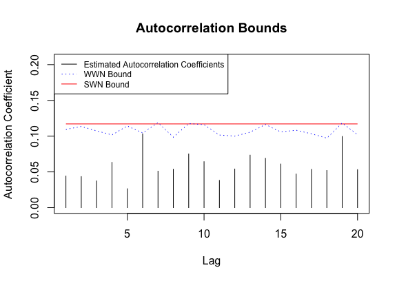

```r
autocorrelation_coeff_plot(f_data = b, K = 20)
```

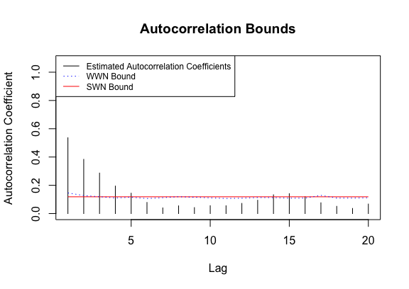

```r
autocorrelation_coeff_plot(f_data = f, K = 20)
```

## The Spectral Density Test [2]

The single-lag test, and in particular, the multi-lag test, are computationally expensive. Another supported test, referred to by its string handle ‘spectral’, which is significantly faster. The drawback of this test, is that it is not built for general white noise (e.g. functional conditionally heteroscedastic) series. It is based on the spectral density operator $\mathscr{F}(\omega) = \frac{1}{2\pi} \sum_{j \in \mathbb{Z}} C(j)e^{-ij\omega}, \omega \in [-\pi, \pi]$, where $C(j)$ are the autocovariance operators, $C(j) = E[X_j \otimes X_0], j \in \mathbb{Z}$. These operators are estimated by $\hat{C}_n(j) = \frac{1}{n} \sum_{t = j+1}^n u_t \otimes u_{t-j}, 0 \le j < n$ and $\hat{\mathscr{F}}_n(\omega) = \frac{1}{2\pi} \sum_{|j|<n} k(\frac{j}{p_n})\hat{C}_n(j)e^{-ij\omega}, \omega \in [-\pi, \pi]$, where $k$ is a user-chosen kernel function and $p_n$ is the bandwidth parameter (or lag-window); it may either be a user-inputted positive integer, computed from the sample size via $p_n = n^{\frac{1}{2q+1}}$, or computed via a data-adaptive process (see Characiejus, Rice [2]). Currently supported kernel functions are the Bartlett and Parzen kernels:
$$\begin{align*}
k_B(x) &= \begin{cases}
1 - |x| & \text{ for } |x| \le 1 \\
0 & \text{ otherwise }
\end{cases} & \text{(Bartlett)}
\\
k_P(x) &= \begin{cases}
1 - 6x^2 + 6|x|^3 & \text{ for } 0 \le |x| \le \frac{1}{2} \\
2(1 - |x|)^3 & \text{ for } \frac{1}{2} \le |x| \le 1 \\
0 & \text{ otherwise }
\end{cases} & \text{(Parzen)}
\end{align*}$$

We then consider the the distance $Q$ (in terms of integrated normed error) between the spectral density operator $\mathscr{F}(\omega), \omega \in [-\pi, \pi]$ and $\frac{1}{2\pi}C(0)$:
$$Q^2 = 2 \pi \int_{-\pi}^{\pi} || \mathscr{F}(\omega) -
\frac{1}{2\pi}C(0)||_2^2 d \omega$$
The test statistic is:
$$T_n = T_n(k, p_n) = \frac{2^{-1} n \hat{Q}_n^2 -
\hat{\sigma}_n^4C_n(k)}{||\hat{C}_n(0)||_2^2 \sqrt{2D_n(k)}}, n \ge 1$$
, where $\hat{\sigma}^2_n = n^{-1} \sum_{t=1}^n ||X_t||^2$, $C_n(k) = \sum_{j=1}^{n-1}(1 - \frac{j}{n})k^2(\frac{j}{p_n})$, and $D_n(k) = \sum_{j=1}^{n-2} (1 - \frac{j}{n})(1 - \frac{j+1}{n})k^4(\frac{j}{p_n})$. We actually use a power transformation of this test statistic proposed by Chen and Deo [5], but this is quite involved and we will omit this (see [2], [5]).

### Applying the Spectral Density Test to Data

We apply the spectral density test to our Brownian motion and FAR data with some different parameter configurations for illustration.

```r
fport_test(b, test='spectral', bandwidth = 'static', suppress_raw_output = TRUE)
```

```
#> Spectral Test
#>
#> null hypothesis: the series is iid
#> p-value = 0.926583
#> sample size = 200
#> kernel function = Bartlett
#> bandwidth = 5.848035
#> bandwidth selection = static
```

```r
fport_test(b, test='spectral', kernel = 'Bartlett', bandwidth = 3, suppress_raw_output = TRUE)
```

```
#> Spectral Test
#>
#> null hypothesis: the series is iid
#> p-value = 0.811402
#> sample size = 200
#> kernel function = Bartlett
#> bandwidth = 3.000000
#> bandwidth selection = 3
```

```r
fport_test(f, test='spectral', kernel = 'Parzen', bandwidth = 10, suppress_raw_output = TRUE)
```

```
#> Spectral Test
#>
#> null hypothesis: the series is iid
#> p-value = 0.000000
#> sample size = 200
#> kernel function = Parzen
#> bandwidth = 10.000000
#> bandwidth selection = 10
```

```r
fport_test(f, test='spectral', bandwidth = 'adaptive', alpha = 0.01, suppress_raw_output = TRUE)
```

```
#> Spectral Test
#>
#> null hypothesis: the series is iid
#> p-value = 0.000000
#> sample size = 200
#> kernel function = Bartlett
#> bandwidth = 16.840540
#> bandwidth selection = adaptive
```

## Independence Test [3]

Performs a test for independence and identical distribution of functional observations. The test relies on a dimensional reduction via a projection of the data on the K most important functional principal components. The empirical autocovariance operator is given by
$$C_N(x) = \frac{1}{N} \sum_{n=1}^N \langle X_n x
\rangle X_n, x \in L^2[0,1)$$
, (where $N$ is the sample size) and the (empirical) eigenelements of $C_N$ are defined by
$$C_N(v_{j,N}) = \lambda_j v_{j,N}, j \ge 1$$
Note, the (non-empirical) eigenfunctions $v_{j}$ form an orthonormal basis of $L^2[0,1)$, and we assume $\lambda_{1,N} \ge \lambda_{2,N} \ge \ldots$, which are all non-negative. We decompose our functional data into its $p$ most important principal components:
$$X_n(t) = \sum_{k=1}^{p} X_{k,n} v_{k,N}$$
, where $X_{k,n} = \int_0^1 X_n(t) v_{k,N}(t)$ Let $\mathbf{C_h}$ denote the sample autocovariance matrix with entries:
$$c_h(k,l) = \frac{1}{N} \sum_{t = 1}^{N-h} X_{k,t}X_{l, t+h}$$
Letting $r_{f,h}(i,j)$ and $r_{b,h}(i,j)$ denote the $(i,j)$ entries of $\mathbf{C_0}^{-1} \mathbf{C_h}$ and $\mathbf{C_h} \mathbf{C_0}^{-1}$, respectively, we define the test statistic:
$$Q_n = N \sum_{h = 1}^H \sum_{i,j = 1}^p r_{f,h}(i,j) r_{b,h}(i,j)$$
, which, under suitable conditions, converges to a $\chi^2_{p^2 H}$ distribution under the null hypothesis. See Gabrys, Kokoszka [3].

### Applying the Independence Test to Data

The ‘components’ parameter (denoted by p above) determines how many functional principal components to use (kept in order of importance, which is determined by the proportion of the variance that each computed component explains). The ‘lag’ parameter (denoted by H above) determines the maximum lag to consider. We apply the independence test to our Brownian motion and FAR data.

```r
fport_test(b, test = 'independence', components = 3, lag = 3, suppress_raw_output = TRUE)
```

```
#> Independence Test
#>
#> null hypothesis: the series is iid
#> p-value = 0.820193
#> number of principal components = 3
#> maximum lag = 3
```

```r
fport_test(f, test = 'independence', components = 16, lag = 10, suppress_raw_output = TRUE)
```

```
#> Independence Test
#>
#> null hypothesis: the series is iid
#> p-value = 0.000087
#> number of principal components = 16
#> maximum lag = 10
```

## References

[1] Kokoszka P., & Rice G., & Shang H.L. (2017). Inference for the autocovariance of a functional time series under conditional heteroscedasticity. Journal of Multivariate Analysis, 162, 32-50, DOI: 10.1016/j.jmva.2017.08.004 .

[2] Characiejus V., & Rice G. (2019). A general white noise test based on kernel lag-window estimates of the spectral density operator. Econometrics and Statistics, DOI: 10.1016/j.ecosta.2019.01.003 .

[3] Gabrys R., & Kokoszka P. (2007). Portmanteau Test of Independence for Functional Observations. Journal of the American Statistical Association, 102:480, 1338-1348, DOI: 10.1198/016214507000001111 .

[4] Zhang X. (2016). White noise testing and model diagnostic checking for functional time series. Journal of Econometrics, 194, 76-95, DOI: 10.1016/j.jeconom.2016.04.004 .

[5] Chen W.W. & Deo R.S. (2004). Power transformations to induce normality and their applications. Journal of the Royal Statistical Society: Series B (Statistical Methodology), 66, 117–130, DOI: 10.1111/j.1467-9868.2004.00435.x .